# 2025 SOE stock status indicator, code update

Abigail Tyrell

09 July, 2025

```r
# create stocksmart-like object from files received from PDB
getstatus <- function(dirfname) {
  # need ABBR name of stock from filename then read in other data
  fname <- stringr::str_split_i(dirfname, "/", -1) # last character in split
  ABBR <- stringr::str_remove(fname, "db.RData.csv")

  statdat <- read.csv(dirfname, header = FALSE)
  statdat[statdat == "?"] <- NA
  statdat <- statdat |>
    dplyr::filter(V2 != "") |>
    tidyr::pivot_wider(names_from = V1, values_from = V2) |>
    dplyr::mutate(`Stock / Entity Name` = ABBR) |>
    dplyr::rename(
      Entity.Name = `Stock / Entity Name`,
      # Fmsy = FMSY,
      F.Fmsy = `F/FMSY`,
      # Estimated.F = `Best F Estimate`,
      # Bmsy = BMSY,
      B.Bmsy = `B/BMSY` # ,
      # Estimated.B =
    )

  return(statdat)
}

prep_for_plotting <- function(data, council = c("MAFMC", "NEFMC")) {
  output <-
    data %>%
    mutate(Code = recode(Code, "Dogfish" = "Sp. Dogfish")) %>%
    # spread(.,Var,Value) %>%
    tidyr::pivot_wider(
      names_from = Var,
      values_from = Value
    ) |>
    filter(Council %in% c(council, "Both")) %>%
    group_by(Stock) %>%
    mutate(score = case_when(
      (B.Bmsy < 0.5) ~ "a",
      (F.Fmsy > 1) ~ "a",
      (F.Fmsy < 1 & B.Bmsy > 0.5 & B.Bmsy < 1) ~ "b",
      (F.Fmsy < 1 & B.Bmsy > 1) ~ "c"
    ))

  return(output)
}

plot_stocksmart <- function(data, xmax, ymax) {
  plt <- data |>
    ggplot() +
    geom_vline(xintercept = 1, linetype = "dotted") +
    geom_vline(xintercept = 0.5, linetype = "dashed") +
    geom_hline(yintercept = 1, linetype = "dashed") +
    geom_point(aes(
      x = B.Bmsy,
      y = F.Fmsy,
      shape = Council,
      color = score
    )) +
    geom_text_repel(
      aes(
        x = B.Bmsy, # geom_text_repel auto-jitters text around points
        y = F.Fmsy,
        label = Code,
        color = score
      ),
      show.legend = FALSE, nudge_y = -0.01, nudge_x = 0.05
    ) +
    scale_color_brewer(
      palette = "Dark2",
      breaks = stock_status$score
    ) +
    ylim(0, ymax) +
    xlim(0, xmax) +
    xlab(expression(~ B / B[msy])) +
    ylab(expression(~ F / F[msy])) +
    guides(color = FALSE) +
    theme_ts()

  return(plt)
}
```

# README

This is a methods test of the stock status indicator. I am trying to re-run the code that Sarah used to create the indicator last year.

# Major Takeaway

Lets try stocksmart today, 31 Oct 2024, and see how much we have to update later if all the assessments aren’t in.

As of 10 Dec 2024 stocksmart is not updated but data for spring 2024 MT assessments were sent via email from Kristan Blackhart to Scott. Dan Hennen created the files.

The file SISspringMT2024.zip has been included here and unzipped into the folder SISspringMT2024.

Stock specific status and output time series are in csv files which I will wrangle and inteleave with stocksmart data as below.

## Pull from `stocksmart` for 2025 SOE reports and add PDB updates

Andy renamed the assessmentdata package [stocksmart](https://noaa-edab.github.io/stocksmart/) based on [Stock SMART](https://www.st.nmfs.noaa.gov/stocksmart?app=homepage).

Two data frames are in the package, `stockAssessmentData` and `stockAssessmentSummary`.

In `stockAssessmentData` we have time series. Columns are StockName, Stockid, Assessmentid, Year, Value, Metric, Description, Units, AssessmentYear, Jurisdiction, FMP, CommonName, ScientificName, ITIS, AssessmentType, StockArea, RegionalEcosystem and the reported metrics are Catch, Fmort, Recruitment, Abundance, Index.

```r
datatable(head(stockAssessmentData), rownames = FALSE, options = list(scrollX = TRUE))
```

| StockName | Stockid | Assessmentid | Year | Value | Metric | Description | Units | AssessmentYear | Jurisdiction | FMP | CommonName | ScientificName | ITIS | AssessmentType | StockArea | RegionalEcosystem |
| --- | --- | --- | --- | --- | --- | --- | --- | --- | --- | --- | --- | --- | --- | --- | --- | --- |
| Acadian redfish - Gulf of Maine / Georges Bank | 10455 | 12882 | 1913 | 7 | Catch | Reported Catch - Total (Mean) | Metric Tons | 2023 | NEFMC | Northeast Multispecies | Acadian redfish | Sebastes fasciatus | 166774 | Operational | Gulf of Maine / Georges Bank | Northeast Shelf |
| Acadian redfish - Gulf of Maine / Georges Bank | 10455 | 12882 | 1914 | 30 | Catch | Reported Catch - Total (Mean) | Metric Tons | 2023 | NEFMC | Northeast Multispecies | Acadian redfish | Sebastes fasciatus | 166774 | Operational | Gulf of Maine / Georges Bank | Northeast Shelf |
| Acadian redfish - Gulf of Maine / Georges Bank | 10455 | 12882 | 1915 | 40 | Catch | Reported Catch - Total (Mean) | Metric Tons | 2023 | NEFMC | Northeast Multispecies | Acadian redfish | Sebastes fasciatus | 166774 | Operational | Gulf of Maine / Georges Bank | Northeast Shelf |
| Acadian redfish - Gulf of Maine / Georges Bank | 10455 | 12882 | 1916 | 53 | Catch | Reported Catch - Total (Mean) | Metric Tons | 2023 | NEFMC | Northeast Multispecies | Acadian redfish | Sebastes fasciatus | 166774 | Operational | Gulf of Maine / Georges Bank | Northeast Shelf |
| Acadian redfish - Gulf of Maine / Georges Bank | 10455 | 12882 | 1917 | 82 | Catch | Reported Catch - Total (Mean) | Metric Tons | 2023 | NEFMC | Northeast Multispecies | Acadian redfish | Sebastes fasciatus | 166774 | Operational | Gulf of Maine / Georges Bank | Northeast Shelf |
| Acadian redfish - Gulf of Maine / Georges Bank | 10455 | 12882 | 1918 | 73 | Catch | Reported Catch - Total (Mean) | Metric Tons | 2023 | NEFMC | Northeast Multispecies | Acadian redfish | Sebastes fasciatus | 166774 | Operational | Gulf of Maine / Georges Bank | Northeast Shelf |

In `stockAssessmentSummary` we have assessment metadata. Columns are Stock ID, Stock Name, Jurisdiction, FMP, Science Center, Regional Ecosystem, FSSI Stock?, ITIS Taxon Serial Number, Scientific Name, Common Name, Stock Area, Assessment ID, Assessment Year, Assessment Month, Last Data Year, Review Result, Assessment Model, Model Version, Lead Lab, Citation, Final Assessment Report 1, Final Assessment Report 2, Point of Contact, Life History Data, Abundance Data, Catch Data, Assessment Level, Assessment Frequency, Model Category, Catch Input Data, Abundance Input Data, Biological Input Data, Ecosystem Linkage, Composition Input Data, F Year, Estimated F, F Unit, F Basis, Flimit, Flimit Basis, Fmsy, Fmsy Basis, F/Flimit, F/Fmsy, Ftarget, Ftarget Basis, F/Ftarget, B Year, Estimated B, B Unit, B Basis, Blimit, Blimit Basis, Bmsy, Bmsy Basis, B/Blimit, B/Bmsy, MSY, MSY Unit, Assessment Type.

```r
datatable(head(stockAssessmentSummary), rownames = FALSE, options = list(scrollX = TRUE))
```

| Stock ID | Stock Name | Jurisdiction | FMP | Science Center | Regional Ecosystem | FSSI Stock? | ITIS Taxon Serial Number | Scientific Name | Common Name | Stock Area | Assessment ID | Assessment Year | Assessment Month | Last Data Year | Review Result | Assessment Model | Model Version | Lead Lab | Citation | Final Assessment Report 1 | Final Assessment Report 2 | Point of Contact | Life History Data | Abundance Data | Catch Data | Assessment Level | Assessment Frequency | Model Category | Catch Input Data | … |
| --- | --- | --- | --- | --- | --- | --- | --- | --- | --- | --- | --- | --- | --- | --- | --- | --- | --- | --- | --- | --- | --- | --- | --- | --- | --- | --- | --- | --- | --- | --- |
| 11089 | Atlantic menhaden - Atlantic Coast | ASMFC | ASMFC Not In FMP | NEFSC / SEFSC | Northeast Shelf / Southeast Shelf | N | 161732 | Brevoortia tyrannus | Atlantic menhaden | Atlantic Coast | 9509 | 2020 | 1 | 2017 | Full acceptance | BAM | Atlantic Menhaden | Beaufort Lab |  | SEDAR 69 Benchmark Stock Assessment Report Atlantic Menhaden |  | melissa.karp@noaa.gov |  |  |  |  |  | 6 | 5 | … |
| 11089 | Atlantic menhaden - Atlantic Coast | ASMFC | ASMFC Not In FMP | NEFSC / SEFSC | Northeast Shelf / Southeast Shelf | N | 161732 | Brevoortia tyrannus | Atlantic menhaden | Atlantic Coast | 12496 | 2022 | 11 | 2021 | Full acceptance | BAM | Atlantic Menhaden | Beaufort Lab |  | 2022�Atlantic�Menhaden�Stock�Assessment�Update� |  | Amy.Schueller@noaa.gov |  |  |  |  |  | 6 | 5 | … |
| 10950 | Albacore - North Atlantic | Atlantic HMS | Consolidated Atlantic Highly Migratory Species | SEFSC | Atlantic Highly Migratory | N | 172419 | Thunnus alalunga | Albacore | North Atlantic | 936 | 2007 | 7 | 2005 | Full acceptance | MultifanCL |  | ICCAT-SCRS | http://www.iccat.int/Documents/Meetings/Docs/2007_ALB%20STOCK%20ASSESS%20REP_AUG_07.pdf | REPORT OF THE 2007 ICCAT ALBACO RE STOCK ASSESSMENT SESSION |  | Victor Restrepo | 2 | 1 | 2 | 4 | 2 |  |  | … |
| 10950 | Albacore - North Atlantic | Atlantic HMS | Consolidated Atlantic Highly Migratory Species | SEFSC | Atlantic Highly Migratory | N | 172419 | Thunnus alalunga | Albacore | North Atlantic | 2245 | 2009 | 10 | 2007 | Full acceptance | Multifan CL |  | ICCAT-SCRS | http://www.iccat.int/Documents/Meetings/Docs/2009_ALB_ASSESS_ENG.pdf | REPORT OF THE 2009 ICCAT ALBACO RE STOCK ASSESSMENT SESSION |  | Michael Schirripa, Craig Brown | 2 | 1 | 2 | 4 | 2 |  |  | … |
| 10950 | Albacore - North Atlantic | Atlantic HMS | Consolidated Atlantic Highly Migratory Species | SEFSC | Atlantic Highly Migratory | N | 172419 | Thunnus alalunga | Albacore | North Atlantic | 3895 | 2013 | 10 | 2011 | Full acceptance | Multifan CL |  | ICCAT-SCRS | http://www.iccat.int/Documents/Meetings/Docs/2013_ALB_ASSESS_REP_ENG.pdf |  |  | Michael Schirripa, Craig Brown | 3 | 1 | 2 | 4 | 2 |  |  | … |
| 10950 | Albacore - North Atlantic | Atlantic HMS | Consolidated Atlantic Highly Migratory Species | SEFSC | Atlantic Highly Migratory | N | 172419 | Thunnus alalunga | Albacore | North Atlantic | 6935 | 2016 | 10 | 2015 | Full acceptance | Aspic |  | ICCAT-SCRS | http://iccat.es/Documents/Meetings/Docs/2016_ALB_REPORT_ENG.pdf | Albacore 2016 Assessment Report |  | Rishi Sharma, Craig Brown | 3 | 1 | 1 | 3 | 2 |  |  | … |

## Supplement with PDB data from Spring 2024 MT assessments

Build a stockSMART like object from PDB files from Spring 2024 MT assessments

```r
stocknames <- data.frame(
  Stock.Name = c(
    "Black sea bass - Mid-Atlantic Coast",
    "Butterfish - Gulf of Maine / Cape Hatteras",
    "Atlantic cod - Eastern Gulf of Maine",
    "Atlantic cod - Georges Bank",
    "Atlantic cod - Southern New England",
    "Atlantic cod - Western Gulf of Maine",
    "Tilefish - Mid-Atlantic Coast",
    "Atlantic herring - Northwestern Atlantic Coast",
    "Atlantic surfclam - Mid-Atlantic Coast"
  ),
  ABBR = c(
    "BSBUNIT",
    "BUTUNIT",
    "CODEGOM",
    "CODGB",
    "CODSNE",
    "CODWGOM",
    "GTFUNIT",
    "HERUNIT",
    "SCUNIT"
  )
)

# get list of filenames and directory paths
fnames <- here::here("SISspringMT2024") |>
  list.files(
    pattern = "db.RData.csv$",
    full.names = TRUE
  )

# purrr map the list of directory paths with getstatus into a dataframe
MTspring24 <- purrr::map_dfr(fnames, getstatus) |>
  # add assessment year
  dplyr::mutate(Assessment.Year = 2024) |>
  # ensure numbers are numeric
  type.convert(as.is = TRUE)

# replace stock ABBR with stocksmart name using lookup
MTspring24$Entity.Name <- stocknames$Stock.Name[match(unlist(MTspring24$Entity.Name), stocknames$ABBR)]
```

Build ecodata input spreadsheet from `stockAssessmentSummary` and use the ecodata code to make the dataset for plotting:

```r
assess2024 <- stocksmart::stockAssessmentSummary |>
  dplyr::filter(`Science Center` == "NEFSC") |>
  dplyr::select(c(
    `Stock Name`, Jurisdiction, FMP, `Science Center`,
    `Stock Area`, `Assessment Year`, `Last Data Year`,
    `F Year`, `Estimated F`, Flimit, Fmsy, `F/Flimit`,
    `F/Fmsy`, Ftarget, `F/Ftarget`, `B Year`, `Estimated B`,
    `B Unit`, Blimit, Bmsy, `B/Blimit`, `B/Bmsy`
  )) |>
  dplyr::arrange(Jurisdiction, `Stock Name`, FMP, `Assessment Year`) |>
  dplyr::rename(
    Entity.Name = `Stock Name`,
    Assessment.Year = `Assessment Year`,
    F.Fmsy = `F/Fmsy`,
    B.Bmsy = `B/Bmsy`,
    Estimated.F = `Estimated F`,
    Estimated.B = `Estimated B`
  )
write.csv(assess2024, here("2025/assess.csv"))
```

Compare `assess2024` to the `MTspring24` data from the PDB files.

PDB data:

```r
MTspring24 |>
  dplyr::select(Entity.Name, Assessment.Year, F.Fmsy, B.Bmsy) |>
  dplyr::arrange(Entity.Name) |>
  knitr::kable()
```

| Entity.Name | Assessment.Year | F.Fmsy | B.Bmsy |
| --- | --- | --- | --- |
| Atlantic cod - Eastern Gulf of Maine | 2024 | 0.020 | 0.12 |
| Atlantic cod - Georges Bank | 2024 | 0.560 | 0.32 |
| Atlantic cod - Southern New England | 2024 | 8.060 | 0.03 |
| Atlantic cod - Western Gulf of Maine | 2024 | 1.630 | 0.03 |
| Atlantic herring - Northwestern Atlantic Coast | 2024 | 0.580 | 0.26 |
| Atlantic surfclam - Mid-Atlantic Coast | 2024 | 0.181 | 0.95 |
| Black sea bass - Mid-Atlantic Coast | 2024 | 0.770 | 2.19 |
| Butterfish - Gulf of Maine / Cape Hatteras | 2024 | 0.030 | 2.22 |
| Tilefish - Mid-Atlantic Coast | 2024 | 1.220 | 0.58 |

Updated stocksmart data for the same species:

```r
assess2024 |>
  dplyr::select(Entity.Name, Assessment.Year, F.Fmsy, B.Bmsy) |>
  dplyr::filter(
    Entity.Name %in% MTspring24$Entity.Name,
    Assessment.Year == 2024
  ) |>
  dplyr::arrange(Entity.Name) |>
  knitr::kable()
```

| Entity.Name | Assessment.Year | F.Fmsy | B.Bmsy |
| --- | --- | --- | --- |
| Atlantic cod - Georges Bank | 2024 | 0.565 | 0.322 |
| Atlantic herring - Northwestern Atlantic Coast | 2024 | 0.584 | 0.257 |
| Atlantic surfclam - Mid-Atlantic Coast | 2024 | 0.183 | 0.950 |
| Black sea bass - Mid-Atlantic Coast | 2024 | 0.770 | 2.189 |
| Butterfish - Gulf of Maine / Cape Hatteras | 2024 | 0.029 | 2.217 |
| Tilefish - Mid-Atlantic Coast | 2024 | 1.223 | 0.582 |

They are the same, within rounding error. It appears that 3 cod stocks are still missing from stocksmart, so we will continue to merge in the PDB data for those stocks.

```r
assessmerge <- assess2024 |>
  dplyr::select(Entity.Name, Assessment.Year, F.Fmsy, B.Bmsy)

MTspring24merge <- MTspring24 |>
  dplyr::select(Entity.Name, Assessment.Year, F.Fmsy, B.Bmsy) |>
  dplyr::mutate(Assessment.Year = as.double(Assessment.Year)) |>
  dplyr::filter(!stringr::str_detect(Entity.Name, "Tilefish")) |> # tilefish already in stocksmart
  dplyr::filter(!Entity.Name %in% assess2024$Entity.Name) # just add the ones that aren't in stocksmart

assess24patch <- dplyr::bind_rows(assessmerge, MTspring24merge)

assess <- assess24patch

## this appears to be a manually built lookup table
decode <- read.csv(here::here("2024decoder.csv"))
write.csv(decode, here("2025/decoder.csv"))

stock_status_stockSMART <-
  assess %>%
  dplyr::group_by(Entity.Name) %>%
  dplyr::filter(Assessment.Year == max(Assessment.Year)) %>%
  # Find last year assessment occurred for each stock
  dplyr::ungroup() %>%
  dplyr::left_join(., decode, by = "Entity.Name") %>% # Join in list of managed species
  dplyr::select(Entity.Name, Assessment.Year, F.Fmsy, B.Bmsy, Council, Code) %>%
  # select column variables to keep
  dplyr::mutate(id = 1:length(Entity.Name)) %>%
  tidyr::gather(., Var, Value, -id, -Entity.Name, -Assessment.Year, -Council, -Code) %>%
  # wide to long
  dplyr::select(-id) %>%
  dplyr::rename(
    `Last assessment` = Assessment.Year,
    Stock = Entity.Name
  ) %>% # rename variables for clarity
  dplyr::mutate(Units = "unitless") # %>%
# dplyr::mutate(Value = replace(Value, which(Code == "N Windowpane" & Var == "F.Fmsy"), NA))

write.csv(stock_status_stockSMART, here("2025/stock_status.csv"), row.names = FALSE)
```

Then test to see if we see the updates relative to SOE 2023 (updates through 2022) ecodata. I’m leaving out all the plot annotations for unknown status.

## Comparisons

### StockSMART Oct 2024 source + patch, Mid-Atlantic

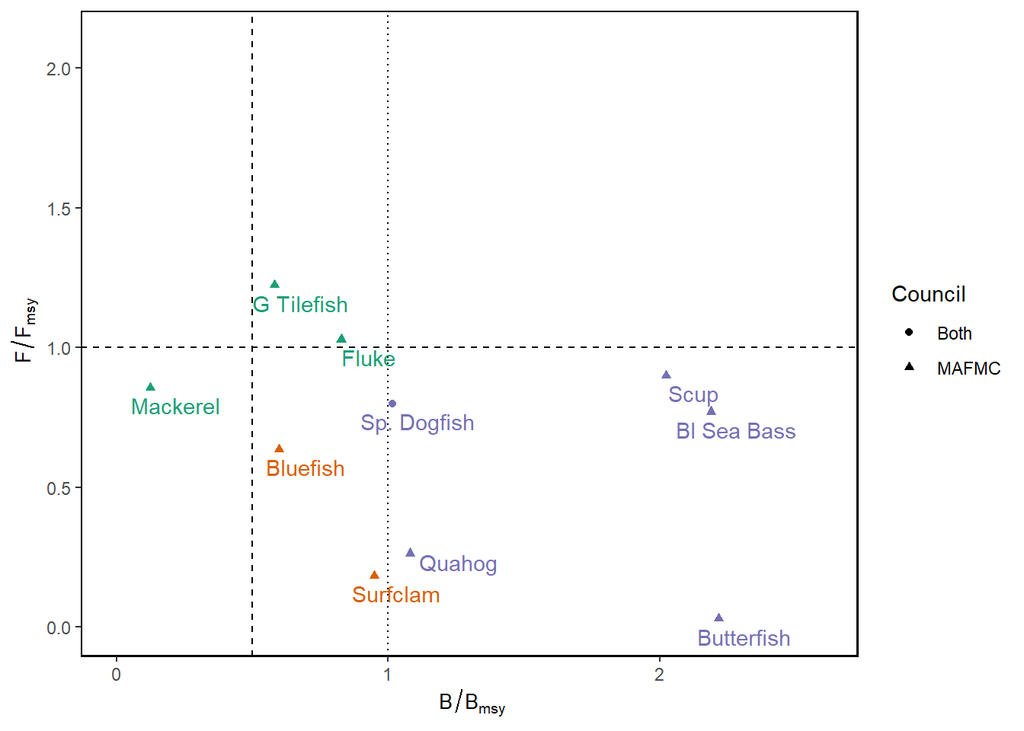

```r
stock_status <- stock_status_stockSMART |>
  prep_for_plotting(council = "MAFMC")

# A dataframe that defines custom legend for stocks with unknown status
# unknown <- data.frame(text = c("Unknown Status", "Longfin Squid",
#                               "Shortfin Squid", "N. Goosefish", "S. Goosefish"),
#                     x = rep(0.9*x.max,5), y = seq(0.93*y.max,1.5,-.1))

# Custom Color -- this isn't used anywhere but keeping for record
custom_color <- c("#56B4E9", "#009E73", "#0072B2")

plot_stocksmart(stock_status, xmax = 2.6, ymax = 2.1)
```

### SOE 2024 ecodata source, Mid-Atlantic

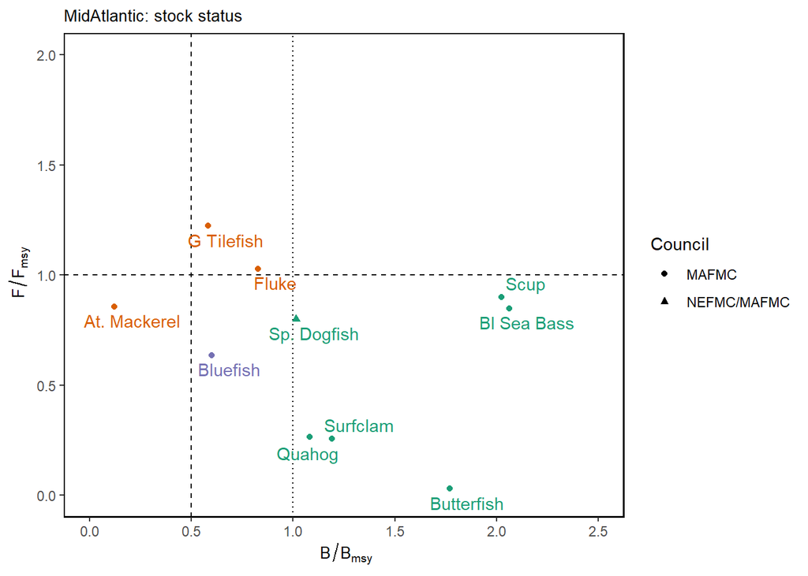

```r
a <- ecodata::plot_stock_status(report = "MidAtlantic")

a$p + ggplot2::coord_cartesian(xlim = c(0, 2.5), ylim = c(0, 2.0))
```

### StockSMART Oct 2024 source + patch, New England

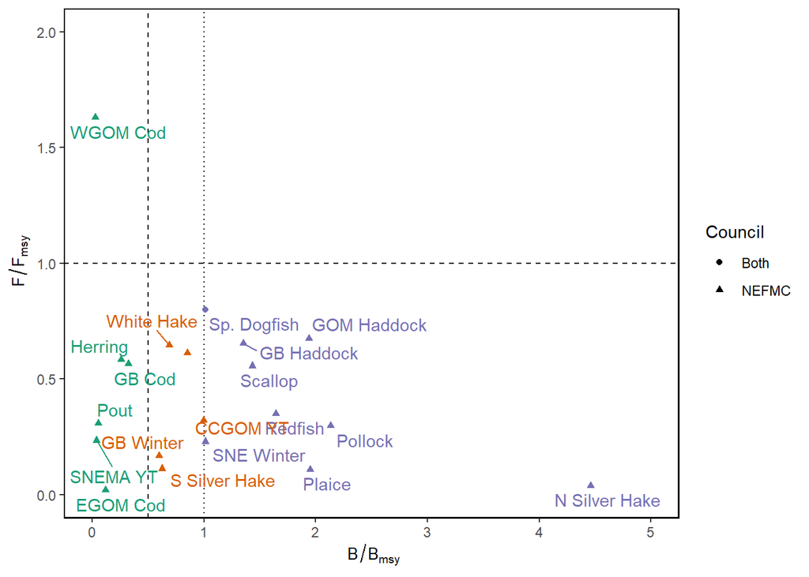

```r
stock_status <- stock_status_stockSMART |>
  prep_for_plotting(council = "NEFMC")

plot_stocksmart(stock_status, xmax = 5, ymax = 2)
```

```r
# doesn't seem like anything is done with this data?
all_missing <- stock_status %>%
  filter(is.na(B.Bmsy), is.na(F.Fmsy)) %>%
  dplyr::select(Code, Council)
b_missing <- stock_status %>%
  filter(is.na(B.Bmsy), !is.na(F.Fmsy)) %>%
  dplyr::select(Code, Council)
f_missing <- stock_status %>%
  filter(is.na(F.Fmsy), !is.na(B.Bmsy)) %>%
  dplyr::select(Code, Council)
# A dataframe that defines custom legend for stocks with unknown status
# all.df <- data.frame(text = all_missing$Code,
#                     x = rep(x.max*0.9,length(all_missing$Code)),
#                     #y = seq(1.45,1.05, length.out = 7))
#                     y = seq(1.45,1.05, length.out = length(all_missing$Code)))
# b.df <- data.frame(text = b_missing$Code,
#                     x = rep(x.max*0.7,length(b_missing$Code)),
#                     y = c(1.45,2.15, length.out = length(b_missing$Code)))
# f.df <- data.frame(text = f_missing$Code,
#                     x = rep(x.max*0.5,length(f_missing$Code)),
#                     y = seq(1.45,1.0, length.out = length(f_missing$Code)))

# Custom Color -- this is not used
custom_color <- c("#56B4E9", "#009E73", "#0072B2")
```

### SOE 2024 ecodata source, New England

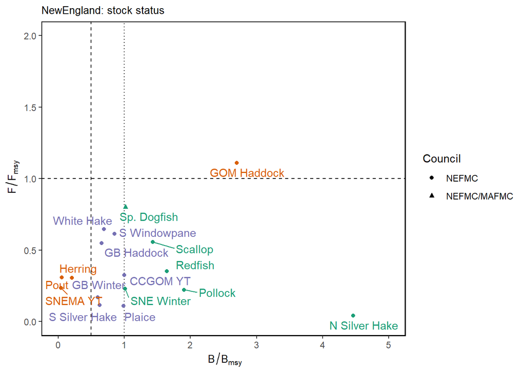

```r
# Get data, spread for plotting, and filter

a <- ecodata::plot_stock_status(report = "NewEngland")
a$p + ggplot2::coord_cartesian(xlim = c(0, 5), ylim = c(0, 2))
```

## Stocks with missing status

```r
stock_status_stockSMART |>
  prep_for_plotting(council = c("MAFMC", "NEFMC")) |>
  dplyr::filter(is.na(F.Fmsy) | is.na(B.Bmsy)) |>
  dplyr::select(Council, Stock, F.Fmsy, B.Bmsy) |>
  knitr::kable()
```

| Council | Stock | F.Fmsy | B.Bmsy |
| --- | --- | --- | --- |
| MAFMC | Longfin inshore squid - Georges Bank / Cape Hatteras | NA | 2.873 |
| MAFMC | Northern shortfin squid - Northwestern Atlantic Coast | NA | NA |
| NEFMC | Atlantic cod - Gulf of Maine | NA | NA |
| NEFMC | Atlantic halibut - Northwestern Atlantic Coast | NA | NA |
| NEFMC | Barndoor skate - Georges Bank / Southern New England | NA | 1.070 |
| NEFMC | Clearnose skate - Southern New England / Mid-Atlantic | NA | 0.802 |
| NEFMC | Little skate - Georges Bank / Southern New England | NA | 0.580 |
| NEFMC | Offshore hake - Northwestern Atlantic Coast | NA | NA |
| NEFMC | Red deepsea crab - Northwestern Atlantic | NA | NA |
| NEFMC | Red hake - Gulf of Maine / Northern Georges Bank | NA | NA |
| NEFMC | Red hake - Southern Georges Bank / Mid-Atlantic | NA | NA |
| NEFMC | Rosette skate - Southern New England / Mid-Atlantic | NA | 1.075 |
| NEFMC | Smooth skate - Gulf of Maine | NA | 0.696 |
| NEFMC | Thorny skate - Gulf of Maine | NA | 0.035 |
| NEFMC | Windowpane - Gulf of Maine / Georges Bank | NA | NA |
| NEFMC | Winter flounder - Gulf of Maine | NA | NA |
| NEFMC | Winter skate - Georges Bank / Southern New England | NA | 1.120 |
| NEFMC | Witch flounder - Northwestern Atlantic Coast | NA | NA |
| NEFMC | Yellowtail flounder - Georges Bank | NA | NA |
| Both | Goosefish - Gulf of Maine / Northern Georges Bank | NA | NA |
| Both | Goosefish - Southern Georges Bank / Mid-Atlantic | NA | NA |

## Issues

This is a patch with preliminary data; stockSMART and `stocksmart` have been not updated as of December 13 2024.